# Milwaukee County and City Evictions Analysis

Rob Wells

8/21/2020

# Analyzing Eviction Court Data From Milwaukee

### Data analysis by Rob Wells

- **The records were scraped from this website**  
  https://wcca.wicourts.gov/advanced.html
- **And processed into this file**  
  https://github.com/Howard-Center-Investigations/evictions/blob/master/cleaning/output/wi_milwaukee/sta_wi_milwaukee_2019_2020.csv
- **Part 1: Load Libraries and Data**

Load Milwaukee City and County Data for Evictions

```r
milw <- rio::import("https://raw.githubusercontent.com/Howard-Center-Investigations/evictions/master/cleaning/output/wi_milwaukee/sta_wi_milwaukee_2019_2020.csv?token=AK7LSTHWMKQIABQRMAYJ64C7JE5YO")
```

- **Clean names**

```r
milw <- janitor::clean_names(milw)
```

```r
glimpse(milw)
```

```
## Rows: 19,423
## Columns: 9
## $ location           <chr> "wi_milwaukee", "wi_milwaukee", "wi_milwaukee…
## $ case_number        <chr> "2020sc004178", "2020sc004174", "2020sc004173…
## $ file_date          <chr> "2020-01-31", "2020-01-31", "2020-01-31", "20…
## $ file_month         <int> 1, 1, 1, 1, 1, 1, 1, 1, 1, 1, 1, 1, 1, 1, 1, …
## $ file_year          <int> 2020, 2020, 2020, 2020, 2020, 2020, 2020, 202…
## $ plaintiff          <chr> "jza milwaukee llc", "lct ii, llc", "lct ii, …
## $ defendant          <chr> "reynolds, shakela", "upchurch, brytni", "oat…
## $ defendant_address  <chr> "5600 n 95th street, unit 7, milwaukee, wi 53…
## $ defendant_attorney <chr> "none", "none", "none", "none", "none", "none…
```

- **Parse Cities**

```r
milw$defendant_address2 <- milw$defendant_address

x <- separate(data = milw, col = defendant_address, into = c("address", "city", "state_zip"), sep = ", ", extra = "merge", fill = "right")
```

```r
x %>%
  group_by(city) %>%
  count(city) %>%
  arrange(desc(n))
```

```
## # A tibble: 991 x 2
## # Groups:   city [991]
##    city                n
##    <chr>           <int>
##  1 milwaukee       14827
##  2 <NA>              545
##  3 west allis        318
##  4 cudahy            108
##  5 south milwaukee    91
##  6 greenfield         82
##  7 #2                 66
##  8 lower              66
##  9 #4                 64
## 10 oak creek          64
## # … with 981 more rows
```

- **Check data fields**

```r
glimpse(milw)
```

```
## Rows: 19,423
## Columns: 10
## $ location           <chr> "wi_milwaukee", "wi_milwaukee", "wi_milwaukee…
## $ case_number        <chr> "2020sc004178", "2020sc004174", "2020sc004173…
## $ file_date          <chr> "2020-01-31", "2020-01-31", "2020-01-31", "20…
## $ file_month         <int> 1, 1, 1, 1, 1, 1, 1, 1, 1, 1, 1, 1, 1, 1, 1, …
## $ file_year          <int> 2020, 2020, 2020, 2020, 2020, 2020, 2020, 202…
## $ plaintiff          <chr> "jza milwaukee llc", "lct ii, llc", "lct ii, …
## $ defendant          <chr> "reynolds, shakela", "upchurch, brytni", "oat…
## $ defendant_address  <chr> "5600 n 95th street, unit 7, milwaukee, wi 53…
## $ defendant_attorney <chr> "none", "none", "none", "none", "none", "none…
## $ defendant_address2 <chr> "5600 n 95th street, unit 7, milwaukee, wi 53…
```

- **Process dates**

```r
#Process dates
milw$date <- ymd(milw$file_date)
```

```r
milw <- milw %>%
  mutate(yearmon = format(date, "%Y-%m"))
```

- **Check data fields**

```r
glimpse(milw)
```

```
## Rows: 19,423
## Columns: 12
## $ location           <chr> "wi_milwaukee", "wi_milwaukee", "wi_milwaukee…
## $ case_number        <chr> "2020sc004178", "2020sc004174", "2020sc004173…
## $ file_date          <chr> "2020-01-31", "2020-01-31", "2020-01-31", "20…
## $ file_month         <int> 1, 1, 1, 1, 1, 1, 1, 1, 1, 1, 1, 1, 1, 1, 1, …
## $ file_year          <int> 2020, 2020, 2020, 2020, 2020, 2020, 2020, 202…
## $ plaintiff          <chr> "jza milwaukee llc", "lct ii, llc", "lct ii, …
## $ defendant          <chr> "reynolds, shakela", "upchurch, brytni", "oat…
## $ defendant_address  <chr> "5600 n 95th street, unit 7, milwaukee, wi 53…
## $ defendant_attorney <chr> "none", "none", "none", "none", "none", "none…
## $ defendant_address2 <chr> "5600 n 95th street, unit 7, milwaukee, wi 53…
## $ date               <date> 2020-01-31, 2020-01-31, 2020-01-31, 2020-01-…
## $ yearmon            <chr> "2020-01", "2020-01", "2020-01", "2020-01", "…
```

- **Filter out records without dates**

```r
milw_bak <- milw
```

```r
milw <- milw %>%
filter(file_date <= as.Date("2020-07-31")) %>%
distinct()
```

### Total Eviction Filings by Month in Milwaukee City and County, Jan. 1 2019-July 31, 2020

**Wisconsin eviction moratorium was March 27 - May 27, 2020**

```r
z <- milw %>%
  group_by(yearmon) %>%
  count(yearmon)
z
```

```
## # A tibble: 19 x 2
## # Groups:   yearmon [19]
##    yearmon     n
##    <chr>   <int>
##  1 2019-01  1029
##  2 2019-02  1133
##  3 2019-03   967
##  4 2019-04   959
##  5 2019-05  1260
##  6 2019-06  1165
##  7 2019-07  1320
##  8 2019-08  1337
##  9 2019-09  1140
## 10 2019-10  1224
## 11 2019-11  1022
## 12 2019-12  1113
## 13 2020-01  1323
## 14 2020-02  1070
## 15 2020-03   432
## 16 2020-04    15
## 17 2020-05    68
## 18 2020-06  1473
## 19 2020-07  1370
```

```r
write.csv(z, "miltotal.8.21.2020.csv")
```

- **Context: Total eviction filings in Wisconsin City and County since Jan. 1, 2019: 19,420**

```r
summary(z$n)
```

```
##    Min. 1st Qu.  Median    Mean 3rd Qu.    Max.
##    15.0   994.5  1133.0  1022.1  1290.0  1473.0
```

```r
sum(z$n)
```

```
## [1] 19420
```

- **Chart of Milwaukee City and County Eviction Filings, Jan 1. 2019-July 31, 2020**  
  **Wisconsin eviction moratorium was March 27 - May 27, 2020**

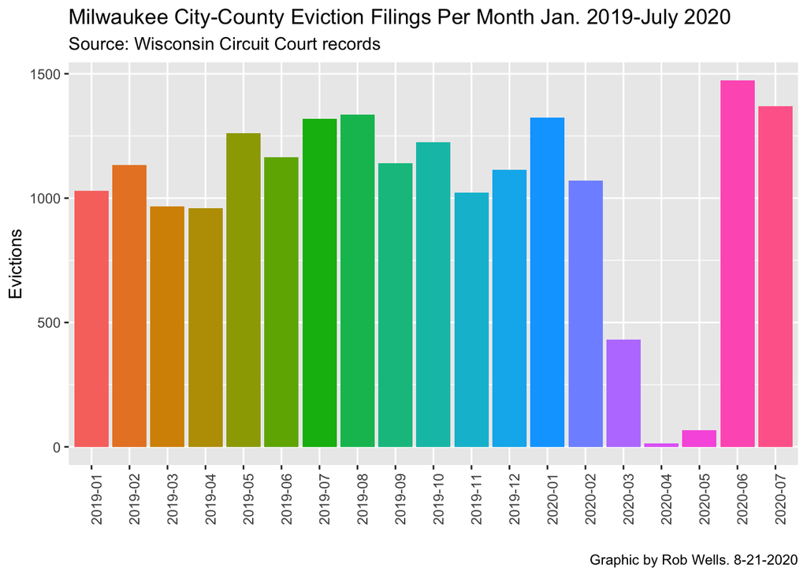

```r
ggplot(z, aes(x=yearmon, y=n, fill=yearmon)) +
  geom_col() +
   theme(axis.text.x = element_text(angle = 90, hjust = 1)) +
  labs(title="Milwaukee City-County Eviction Filings Per Month Jan. 2019-July 2020",y="Evictions", x= "",
       caption = "Graphic by Rob Wells. 8-21-2020", subtitle = "Source: Wisconsin Circuit Court records")+
  theme(legend.position="none")
```

```r
ggsave("Milw_Evict_8_21_2020.png",device = "png",width=9,height=6, dpi=500)
```

- **Clean the columns - remove stray spaces**

```r
p <- milw
```

```r
p$plaintiff_one <- str_trim(p$plaintiff)
p$defendant_one <- str_trim(p$defendant)
p$plaintiff_one <- gsub("[[:punct:]]", "", p$plaintiff_one)
p$plaintiff_one <- gsub("[[:punct:]]", "", p$plaintiff_one)
p$defendant_one <- gsub("[[:punct:]]", "", p$defendant_one)
head(p)
```

```
##       location  case_number  file_date file_month file_year
## 1 wi_milwaukee 2020sc004178 2020-01-31          1      2020
## 2 wi_milwaukee 2020sc004174 2020-01-31          1      2020
## 3 wi_milwaukee 2020sc004173 2020-01-31          1      2020
## 4 wi_milwaukee 2020sc004170 2020-01-31          1      2020
## 5 wi_milwaukee 2020sc003834 2020-01-31          1      2020
## 6 wi_milwaukee 2020sc003831 2020-01-31          1      2020
##           plaintiff           defendant
## 1 jza milwaukee llc   reynolds, shakela
## 2       lct ii, llc    upchurch, brytni
## 3       lct ii, llc    oates, traveon d
## 4 jza milwaukee llc   southaphan, nancy
## 5     bc management williams, elizabeth
## 6     bc management         elias, kely
##                                     defendant_address defendant_attorney
```

[output cut: 20 more lines]

- **Remove numerals from names**

```r
p$plaintiff_one <- gsub("[0-9]", "", p$plaintiff_one)
head(p)
```

```
##       location  case_number  file_date file_month file_year
## 1 wi_milwaukee 2020sc004178 2020-01-31          1      2020
## 2 wi_milwaukee 2020sc004174 2020-01-31          1      2020
## 3 wi_milwaukee 2020sc004173 2020-01-31          1      2020
## 4 wi_milwaukee 2020sc004170 2020-01-31          1      2020
## 5 wi_milwaukee 2020sc003834 2020-01-31          1      2020
## 6 wi_milwaukee 2020sc003831 2020-01-31          1      2020
##           plaintiff           defendant
## 1 jza milwaukee llc   reynolds, shakela
## 2       lct ii, llc    upchurch, brytni
## 3       lct ii, llc    oates, traveon d
## 4 jza milwaukee llc   southaphan, nancy
## 5     bc management williams, elizabeth
## 6     bc management         elias, kely
##                                     defendant_address defendant_attorney
```

[output cut: 20 more lines]

- **Summary of Milwaukee Plaintiffs**

```r
#Build a simple summary table
plaintiff1 <- p %>%
  select(plaintiff_one, defendant_one, date) %>%
         group_by(plaintiff_one) %>%
         count(plaintiff_one) %>%
         ungroup() %>%
         arrange(desc(n))

write.csv(plaintiff1, "milplaintiff.7.6.2020.csv")


plaintiff1
```

```
## # A tibble: 5,808 x 2
##    plaintiff_one                                  n
##    <chr>                                      <int>
##  1 berrada properties  llc                     1209
##  2 metropolitan associates                      323
##  3 falcon crest llc                             198
##  4 s real estate                                162
##  5 city of milwaukee                            156
##  6 housing authority of the city of milwaukee   144
##  7 guardian investment real estate company      124
##  8 bruckner daniel w                            111
##  9 mariners pointe apartments llc               101
## 10 meaux park llc                                98
## # … with 5,798 more rows
```

```r
#quick fact check on totals: 19,420 checks out
sum(plaintiff1$n)
```

```
## [1] 19420
```

- **Context**: During the entire course of this study, the 19,420 eviction records since January 2019, the average number of evictions by a landlord was 3.

```r
summary(plaintiff1)
```

```
##  plaintiff_one            n
##  Length:5808        Min.   :   1.000
##  Class :character   1st Qu.:   1.000
##  Mode  :character   Median :   1.000
##                     Mean   :   3.344
##                     3rd Qu.:   2.000
##                     Max.   :1209.000
```

- **Milwaukee City and County all since March 27 2020: 2,929 Eviction Filings**

```r
x <- p %>%
  filter(date > '2020-03-27')

write.csv(x, "mil_all_march27forward.csv")
```

- **Milwaukee City - County evictions / Plaintiffs since March 27 2020**

```r
moratorium <- p %>%
  filter(date > '2020-03-27') %>%
  select(plaintiff_one, defendant_one, date) %>%
         group_by(plaintiff_one) %>%
         count(plaintiff_one) %>%
         ungroup() %>%
         arrange(desc(n))

write.csv(moratorium, "milplaintiff.8.4.2020.csv")
```

- **Context: Total Evictions in Milwaukee City - County since March 27, 2020: 2,929**

```r
sum(moratorium$n)
```

```
## [1] 2929
```

- **Milwaukee City - County Plaintiffs since March 27 2020**

```r
top <- p %>%
  filter(date > '2020-03-27') %>%
  select(plaintiff_one, yearmon) %>%
         group_by(plaintiff_one, yearmon) %>%
         count(plaintiff_one) %>%
         filter(n > 5) %>%
         ungroup() %>%
         arrange(yearmon) %>%
         arrange(desc(n))
write.csv(top, "mil_evictors_mo_8_4_2020.csv")
head(top)
```

```
## # A tibble: 6 x 3
##   plaintiff_one                           yearmon     n
##   <chr>                                   <chr>   <int>
## 1 berrada properties  llc                 2020-06   162
## 2 berrada properties  llc                 2020-07   144
## 3 s real estate                           2020-06    40
## 4 falcon crest llc                        2020-07    22
## 5 metropolitan associates                 2020-06    18
## 6 guardian investment real estate company 2020-06    17
```

- **Context**: Since the moratorium, the 2,929 eviction records since March 27, 2020, the average number of evictions by a landlord was 2.

```r
summary(moratorium)
```

```
##  plaintiff_one            n
##  Length:1386        Min.   :  1.000
##  Class :character   1st Qu.:  1.000
##  Mode  :character   Median :  1.000
##                     Mean   :  2.113
##                     3rd Qu.:  2.000
##                     Max.   :306.000
```

##Cleaning of Plaintiffs Names, Normalizing and Grouping

```r
p2 <- p
```

```r
p2$plaintiff_fixed <- p2$plaintiff_one
```

```r
glimpse(p2)
```

```
## Rows: 19,420
## Columns: 15
## $ location           <chr> "wi_milwaukee", "wi_milwaukee", "wi_milwaukee…
## $ case_number        <chr> "2020sc004178", "2020sc004174", "2020sc004173…
## $ file_date          <chr> "2020-01-31", "2020-01-31", "2020-01-31", "20…
## $ file_month         <int> 1, 1, 1, 1, 1, 1, 1, 1, 1, 1, 1, 1, 1, 1, 1, …
## $ file_year          <int> 2020, 2020, 2020, 2020, 2020, 2020, 2020, 202…
## $ plaintiff          <chr> "jza milwaukee llc", "lct ii, llc", "lct ii, …
## $ defendant          <chr> "reynolds, shakela", "upchurch, brytni", "oat…
## $ defendant_address  <chr> "5600 n 95th street, unit 7, milwaukee, wi 53…
## $ defendant_attorney <chr> "none", "none", "none", "none", "none", "none…
## $ defendant_address2 <chr> "5600 n 95th street, unit 7, milwaukee, wi 53…
## $ date               <date> 2020-01-31, 2020-01-31, 2020-01-31, 2020-01-…
## $ yearmon            <chr> "2020-01", "2020-01", "2020-01", "2020-01", "…
## $ plaintiff_one      <chr> "jza milwaukee llc", "lct ii llc", "lct ii ll…
## $ defendant_one      <chr> "reynolds shakela", "upchurch brytni", "oates…
## $ plaintiff_fixed    <chr> "jza milwaukee llc", "lct ii llc", "lct ii ll…
```

- **Rename and Group Landlords, Substitute top names and normalize**

```r
p2 <- p2 %>%
  mutate(plaintiff_fixed = case_when(plaintiff_one=="meaux park llc" ~ "berrada",
                                     plaintiff_one=="berrada properties  llc" ~ "berrada",
                                     plaintiff_one=="spring court apartments llc" ~ "berrada",
                                     plaintiff_one=="dineen park townhomes llc" ~ "berrada",
                                     plaintiff_one=="arbor gardens apartments llc" ~ "berrada",
                                     plaintiff_one=="luther haven llc" ~ "berrada",
                                     plaintiff_one=="willow court apartments llc" ~ "berrada",
                                     plaintiff_one=="garden terrace homes llc" ~ "berrada",
                                     plaintiff_one=="good hope townhomes ii llc" ~ "berrada",
                                     plaintiff_one=="good hope townhomes llc" ~ "berrada",
                                     plaintiff_one=="colonial pointe ii apartments llc" ~ "berrada",
                                     plaintiff_one=="colonial pointe il apartments llc" ~ "berrada",
                                     plaintiff_one=="colonial pointe i apartments llc" ~ "berrada",
                                     plaintiff_one=="mariners pointe apartments llc" ~ "berrada",
                                     plaintiff_one=="berrada properties llc" ~ "berrada",
                                     plaintiff_one=="yb florist llc" ~ "berrada",
                                     plaintiff_one=="yb medford llc" ~ "berrada",
                                     plaintiff_one=="yb silver spring llc" ~ "berrada",
                                     plaintiff_one=="yb victory llc" ~ "berrada",
                                     plaintiff_one=="falcon crest llc" ~ "berrada",
                                     plaintiff_one=="wisniewski michael s" ~ "michael_s_wisniewski",
                                     plaintiff_one=="bruckner daniel w" ~ "daniel_w_bruckner",
                                     plaintiff_one=="nawrocki gregory w" ~ "gregory_w_nawrocki",
                                     plaintiff_one=="nawrocki gregory" ~ "gregory_w_nawrocki",
                                     plaintiff_one=="nawrocki gragory w" ~ "gregory_w_nawrocki",
                                     plaintiff_one=="martin bruce" ~ "bruce_martin",
                                     plaintiff_one=="housing authority of the city of milwaukee" ~ "milwaukee_city_housing_authority",
                                     plaintiff_one=="city of milwaukee" ~ "milwaukee_city",
                                     plaintiff_one=="city  of milwaukee" ~ "milwaukee_city",
                                     plaintiff_one=="milwaukee living llc" ~ "milwaukee_living",
                                     plaintiff_one=="milwaukee capital properties llc" ~ "milwaukee_capital_properties",
                                     plaintiff_one=="good hope townhomes ii llc" ~ "good_hope_townhomes",
                                     plaintiff_one=="good hope townhomes llc" ~ "good_hope_townhomes",
                                     plaintiff_one=="howard and th street holding company" ~ "howard_76_st_holding_co",
                                     plaintiff_one=="maas robert" ~ "robert_maas",
                                     plaintiff_one=="maas robert j" ~ "robert_maas",
                                     plaintiff_one=="atlantis properties llc" ~ "anchor_properties",
                                     plaintiff_one=="anchor properties llc" ~ "anchor_properties",
                                      plaintiff_one=="action properties llc" ~ "anchor_properties",
                                     plaintiff_one=="afc properties llc" ~ "anchor_properties",
                                     plaintiff_one=="atunna properties llc" ~ "anchor_properties",
                                     plaintiff_one=="affordable properties llc" ~ "anchor_properties",
                                     plaintiff_one=="acme properties  llc" ~ "anchor_properties",
                                     plaintiff_one=="alotta properties llc" ~ "anchor_properties",
                                     plaintiff_one=="anumbera properties llc" ~ "anchor_properties",
                                     plaintiff_one=="allsortsa properties llc" ~ "anchor_properties",
                                     plaintiff_one=="absolute properties llc" ~ "anchor_properties",
                                    TRUE~plaintiff_one))
```

```r
#Save as a csv
write.csv(p2, "milw_landlord_cleaned_8_6_2020.csv")
```

- **Simple table for fact checking on normalization of names**

```r
pp2 <- p2 %>%
  select(plaintiff_one, plaintiff_fixed)
```

- **Context**: Berrada properties and its 18 affiliates were responsible for 2,230 eviction filings in Milwaukee City and County, or at least 11% of all 19,420 eviction filings since January 2019. Anchor Properties and its affiliates accounted for 3% of filings.

```r
#Summary of Cleaned Milwaukee Plaintiffs
plaintiff2 <- p2 %>%
  select(plaintiff_fixed, date) %>%
         group_by(plaintiff_fixed) %>%
         count(plaintiff_fixed) %>%
         ungroup() %>%
         arrange(desc(n))

write.csv(plaintiff2, "milplaintiff.cleaned.8.4.2020.csv")


plaintiff2
```

```
## # A tibble: 5,777 x 2
##    plaintiff_fixed                               n
##    <chr>                                     <int>
##  1 "berrada"                                  2230
##  2 "anchor_properties"                         595
##  3 "metropolitan associates"                   323
##  4 "s real estate"                             162
##  5 "milwaukee_city"                            156
##  6 "milwaukee_city_housing_authority"          144
##  7 "guardian investment real estate company"   124
##  8 "daniel_w_bruckner"                         111
##  9 "gregory_w_nawrocki"                        105
## 10 " highland llc"                              90
## # … with 5,767 more rows
```

- **Context: Berrada was responsible for 17% of eviction filings in Milwaukee City and County since March 27, 2020.** Since the moratorium started in March 27, 2020, there have been 2,929 evictions. Berrada and its 18 affiliated entities had 484 eviction filings, or 17% of the total. Anchor and its affiliates were responsible for 4% of eviction filings.

```r
#Cleaned Milwaukee Plaintiffs since March 27 2020
top2 <- p2 %>%
  filter(date > '2020-03-27') %>%
  select(plaintiff_fixed, yearmon) %>%
         group_by(plaintiff_fixed) %>%
         count(plaintiff_fixed) %>%
         filter(n > 5) %>%
         ungroup() %>%
         arrange(desc(n))
write.csv(top2, "cleaned_mil_evictors_since_March27_8_5_2020.csv")
top2
```

```
## # A tibble: 53 x 2
##    plaintiff_fixed                               n
##    <chr>                                     <int>
##  1 "berrada"                                   484
##  2 "anchor_properties"                         119
##  3 "s real estate"                              54
##  4 "gregory_w_nawrocki"                         30
##  5 "daniel_w_bruckner"                          26
##  6 " highland llc"                              25
##  7 "guardian investment real estate company"    24
##  8 "metropolitan associates"                    19
##  9 "milwaukee_capital_properties"               17
## 10 "scv ventures  llc"                          17
## # … with 43 more rows
```

- **Top with top 50 Results of Milwaukee Landlords**

```r
top2 %>%
  top_n(50, n) %>%
  kable() %>%
  kable_styling("striped")
```

| plaintiff_fixed | n |
| --- | --- |
| berrada | 484 |
| anchor_properties | 119 |
| s real estate | 54 |
| gregory_w_nawrocki | 30 |
| daniel_w_bruckner | 26 |
| highland llc | 25 |
| guardian investment real estate company | 24 |
| metropolitan associates | 19 |
| milwaukee_capital_properties | 17 |
| scv ventures llc | 17 |
| copper kettle ltd rprf ii | 16 |
| bruce_martin | 15 |
| abuncha properties llc | 14 |
| michael_s_wisniewski | 12 |
| morocco investments llc | 10 |
| riddlebrook llc | 10 |
| romboy investments llc | 10 |
| sac llc | 10 |
| awesome properties llc | 9 |
| breeze property holdings ii llc | 9 |
| milwaukee_city | 9 |
| te i llc | 9 |
| te iii llc | 9 |
| llc | 8 |
| accurate properties llc | 8 |
| active properties llc | 8 |
| kb co llc co kb company investments inc | 8 |
| martin renee | 8 |
| sessler properties llc | 8 |
| spring park apartments llc | 8 |
| aardvark properties llc | 7 |
| brunner shawn | 7 |
| cimbalnik mark | 7 |
| college mhp llc | 7 |
| geo investments llc | 7 |
| iceman llc | 7 |
| kich enterprises llc | 7 |
| milwaukee_city_housing_authority | 7 |
| penguin property holdings llc | 7 |
| rms investments llc | 7 |
| sherard will j | 7 |
| tas solutions llc | 7 |
| vb one llc | 7 |
| n th street llc | 6 |
| w wisconsin llc | 6 |
| west llc | 6 |
| aloha properties llc | 6 |
| bcv ii holdings llc | 6 |
| coleman mesteshia | 6 |
| dls investment properties llc | 6 |
| holloway living trustatkinson apartments | 6 |
| sudden valley llc | 6 |
| the empire llc | 6 |

- **Cleaned Milwaukee Plaintiffs by Month since March 27 2020**

```r
top3 <- p2 %>%
  filter(date > '2020-03-27') %>%
  select(plaintiff_fixed, yearmon) %>%
         group_by(plaintiff_fixed, yearmon) %>%
         count(plaintiff_fixed) %>%
         filter(n > 5) %>%
         ungroup() %>%
         arrange(yearmon) %>%
         arrange(desc(n))
write.csv(top3, "cleaned_mil_evictors_mo_8_4_2020.csv")
head(top3)
```

```
## # A tibble: 6 x 3
##   plaintiff_fixed         yearmon     n
##   <chr>                   <chr>   <int>
## 1 berrada                 2020-06   247
## 2 berrada                 2020-07   237
## 3 anchor_properties       2020-06    77
## 4 anchor_properties       2020-07    42
## 5 s real estate           2020-06    40
## 6 metropolitan associates 2020-06    18
```

**–30–**